# Liquid-Chromatography Retention Order Prediction for Metabolite Identification

Eric Bach, Sandor Szedmak, Celine Brouard, Sebastian Böcker and Juho Rousu

July 01, 2018

# Experimental results: Retention order prediction (Section 3.1)

## Accuracy of binary vs. counting fingerprints (Section 3.1.3)

Comparison of the pairwise prediction performance using binary and counting MACCS fingerprints as predictor (see Table 3).

| target_system | pairwise_accuracy | pairwise_accuracy_2std | predictor |
| --- | --- | --- | --- |
| Eawag_XBridgeC18 | 0.844 | 0.011 | maccsCount_f2dcf0b3 |
| FEM_long | 0.905 | 0.015 | maccsCount_f2dcf0b3 |
| LIFE_old | 0.862 | 0.035 | maccsCount_f2dcf0b3 |
| RIKEN | 0.848 | 0.017 | maccsCount_f2dcf0b3 |
| UFZ_Phenomenex | 0.802 | 0.017 | maccsCount_f2dcf0b3 |
| Eawag_XBridgeC18 | 0.796 | 0.015 | maccs |
| FEM_long | 0.882 | 0.016 | maccs |
| LIFE_old | 0.842 | 0.050 | maccs |
| RIKEN | 0.826 | 0.024 | maccs |
| UFZ_Phenomenex | 0.790 | 0.027 | maccs |

The following results are based on MACCS counting fingerprints.

## Retention order prediction: RankSVM vs. SVR (Section 3.1.4)

Comparison of RankSVM and SVR pairwise prediction accuracy.

### Single system for training

A single system is used for the training. The performance is evaluated in target system used for training. Remember, we use cross-validation for the performance evaluation. The results are shown in Table 4 in the paper (*Single system, target data only*).

| target_system | pairwise_accuracy | pairwise_accuracy_2std | estimator |
| --- | --- | --- | --- |
| Eawag_XBridgeC18 | 0.844 | 0.011 | RankSVM |
| FEM_long | 0.905 | 0.015 | RankSVM |
| LIFE_old | 0.862 | 0.035 | RankSVM |
| RIKEN | 0.848 | 0.017 | RankSVM |
| UFZ_Phenomenex | 0.802 | 0.017 | RankSVM |
| Eawag_XBridgeC18 | 0.846 | 0.011 | SVR |
| FEM_long | 0.904 | 0.014 | SVR |
| LIFE_old | 0.860 | 0.028 | SVR |
| RIKEN | 0.842 | 0.020 | SVR |
| UFZ_Phenomenex | 0.796 | 0.023 | SVR |

### Multiple systems for training

All systems in the dataset are used for training. We vary the percentage of target system data used for training from 0% (10%) to 100%. The resulting curves are averaged across all target systems (Figure 4).

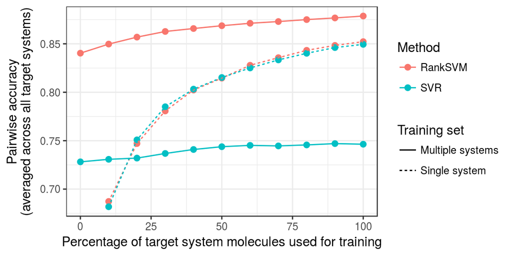

Effect of training data from other chromatographic system in addition per target system (Figure not included in the paper):

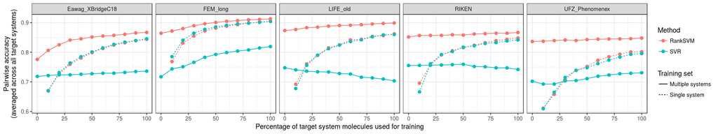

Result shown in Table 4.

| target_system | sysset | pairwise_accuracy | pairwise_accuracy_2std | estimator | perc |
| --- | --- | --- | --- | --- | --- |
| Eawag_XBridgeC18 | Single system | 0.844 | 0.011 | RankSVM | 100 |
| FEM_long | Single system | 0.905 | 0.015 | RankSVM | 100 |
| LIFE_old | Single system | 0.862 | 0.035 | RankSVM | 100 |
| RIKEN | Single system | 0.848 | 0.017 | RankSVM | 100 |
| UFZ_Phenomenex | Single system | 0.802 | 0.017 | RankSVM | 100 |
| Eawag_XBridgeC18 | Single system | 0.846 | 0.011 | SVR | 100 |
| FEM_long | Single system | 0.904 | 0.014 | SVR | 100 |
| LIFE_old | Single system | 0.860 | 0.028 | SVR | 100 |
| RIKEN | Single system | 0.842 | 0.020 | SVR | 100 |
| UFZ_Phenomenex | Single system | 0.796 | 0.023 | SVR | 100 |
| Eawag_XBridgeC18 | Multiple systems | 0.867 | 0.011 | RankSVM | 100 |
| FEM_long | Multiple systems | 0.913 | 0.009 | RankSVM | 100 |
| LIFE_old | Multiple systems | 0.899 | 0.018 | RankSVM | 100 |
| RIKEN | Multiple systems | 0.867 | 0.012 | RankSVM | 100 |
| UFZ_Phenomenex | Multiple systems | 0.848 | 0.009 | RankSVM | 100 |
| Eawag_XBridgeC18 | Multiple systems | 0.736 | 0.014 | SVR | 100 |
| FEM_long | Multiple systems | 0.819 | 0.011 | SVR | 100 |
| LIFE_old | Multiple systems | 0.704 | 0.046 | SVR | 100 |
| RIKEN | Multiple systems | 0.742 | 0.015 | SVR | 100 |
| UFZ_Phenomenex | Multiple systems | 0.731 | 0.017 | SVR | 100 |
| Eawag_XBridgeC18 | Multiple systems | 0.776 | 0.012 | RankSVM | 0 |
| FEM_long | Multiple systems | 0.864 | 0.010 | RankSVM | 0 |
| LIFE_old | Multiple systems | 0.873 | 0.019 | RankSVM | 0 |
| RIKEN | Multiple systems | 0.852 | 0.010 | RankSVM | 0 |
| UFZ_Phenomenex | Multiple systems | 0.836 | 0.013 | RankSVM | 0 |
| Eawag_XBridgeC18 | Multiple systems | 0.719 | 0.006 | SVR | 0 |
| FEM_long | Multiple systems | 0.717 | 0.020 | SVR | 0 |
| LIFE_old | Multiple systems | 0.748 | 0.029 | SVR | 0 |
| RIKEN | Multiple systems | 0.755 | 0.018 | SVR | 0 |
| UFZ_Phenomenex | Multiple systems | 0.702 | 0.021 | SVR | 0 |

# Experimental results: Metabolite identification (Section 3.2)

Average percentage of correctly identified molecular structures for different values of $D$ (Figure 5).

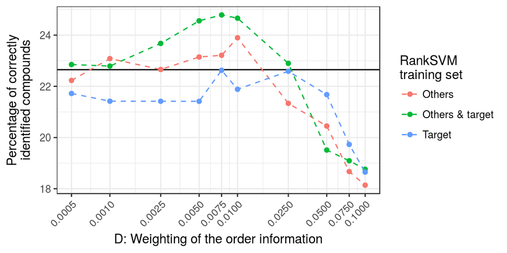

Significants test for $D$ with maximum identification accuracy:

- Others & target:

```r
t.test(df_top1acc_FINAL_s10_imp[D == 0.0075]$top1_acc, mu = mean (df_top1acc_FINAL_s10_imp[D == 0]$top1_acc))
```

```
##
##  One Sample t-test
##
## data:  df_top1acc_FINAL_s10_imp[D == 0.0075]$top1_acc
## t = 21.559, df = 999, p-value < 2.2e-16
## alternative hypothesis: true mean is not equal to 22.65
## 95 percent confidence interval:
##  24.59521 24.98479
## sample estimates:
## mean of x
##     24.79
```

- Others:

```r
t.test(df_top1acc_FINAL_s10[D == 0.01]$top1_acc, mu = mean (df_top1acc_FINAL_s10[D == 0]$top1_acc))
```

```
##
##  One Sample t-test
##
## data:  df_top1acc_FINAL_s10[D == 0.01]$top1_acc
## t = 12.767, df = 999, p-value < 2.2e-16
## alternative hypothesis: true mean is not equal to 22.65
## 95 percent confidence interval:
##  23.70576 24.08924
## sample estimates:
## mean of x
##   23.8975
```

- Target:

```r
t.test(df_top1acc_FINAL_imp[D == 0.0075]$top1_acc, mu = mean (df_top1acc_FINAL_imp[D == 0]$top1_acc))
```

```
##
##  One Sample t-test
##
## data:  df_top1acc_FINAL_imp[D == 0.0075]$top1_acc
## t = -0.25154, df = 999, p-value = 0.8014
## alternative hypothesis: true mean is not equal to 22.65
## 95 percent confidence interval:
##  22.45197 22.80303
## sample estimates:
## mean of x
##   22.6275
```